# Binary choices: interpreting probit and logit

### Step 2 · Conditional and average slopes

**Question:** Is price equally influential at every starting probability?  
**Prediction:** no; the CDF is steepest near the centre of its index (R3), and AME and MEM need not coincide (R7).  
**Action:** inspect three local slopes, the average across sampled shoppers, and the slope at the averaged shopper.

```r
profiles <- data.frame(pratio = c(0.8, 1.1, 1.5),
                       disp_coke = 0, disp_pepsi = 0)
slopes(logit, variables = "pratio", newdata = profiles)
```

```
 Estimate Std. Error      z Pr(>|z|)    S  2.5 % 97.5 %
   -0.486     0.0720  -6.75   <0.001 36.0 -0.627 -0.345
   -0.490     0.0753  -6.50   <0.001 33.6 -0.637 -0.342
   -0.379     0.0345 -11.01   <0.001 91.3 -0.447 -0.312

Term: pratio
Type: response
Comparison: dY/dX
```

```r
avg_slopes(logit, variables = "pratio")                  # AME
```

```
 Estimate Std. Error     z Pr(>|z|)    S  2.5 % 97.5 %
   -0.433     0.0639 -6.78   <0.001 36.2 -0.559 -0.308

Term: pratio
Type: response
Comparison: dY/dX
```

```r
slopes(logit, variables = "pratio", newdata = "mean")    # MEM
```

```
 Estimate Std. Error     z Pr(>|z|)    S 2.5 % 97.5 %
   -0.497     0.0781 -6.36   <0.001 32.2 -0.65 -0.344

Term: pratio
Type: response
Comparison: dY/dX
```

```r
# R7 by hand: AME averages f(eta_i); MEM evaluates f at the mean index.
p_i <- fitted(logit)
x_bar <- c(1, colMeans(coke[, c("pratio", "disp_coke", "disp_pepsi")]))
p_bar <- plogis(sum(x_bar * b))
c(AME = mean(p_i * (1 - p_i)) * b[["pratio"]],
  MEM = p_bar * (1 - p_bar) * b[["pratio"]])
```

```
       AME        MEM
-0.4332630 -0.4905964
```

```r
# Is the whole index inside the region where the logistic density is concave?
eta_i <- predict(logit, type = "link")
c(min_eta = min(eta_i), max_eta = max(eta_i),
  concave_bound = log(2 + sqrt(3)),
  share_in_concave_region = mean(abs(eta_i) < log(2 + sqrt(3))))
```

```
                min_eta                 max_eta           concave_bound
             -3.4474650               1.2822751               1.3169579
share_in_concave_region
              0.8692982
```

**Interpretation/decision:** A slope of $-0.4$ would mean a decrease of approximately **4 percentage points** for a 0.1 increase, locally, not a 40% lower probability.  
The middle row should equal `slope_by_hand` from Step 0.  
An average marginal effect (AME) averages observation-specific slopes; it is different from a slope computed at averaged covariates.  
Not every fitted index lies in the concave region, yet $|\text{AME}|<|\text{MEM}|$: concavity over the whole support is sufficient for R7’s inequality, not necessary.

### Step 3 · The actual proposed change

**Question:** What does raising the ratio from 1.0 to 1.1 do for one shopper without displays?  
**Prediction:** a negative probability difference; by R5, close to the local slope times 0.1 if $p$ is near 0.5, less close otherwise.  
**Action:**

```r
price_pair <- data.frame(pratio = c(1.0, 1.1), disp_coke = 0, disp_pepsi = 0)
p_pair <- predict(logit, price_pair, type = "response")
data.frame(price_pair, probability = p_pair)
```

```
  pratio disp_coke disp_pepsi probability
1    1.0         0          0   0.4818156
2    1.1         0          0   0.4323318
```

```r
# R5: exact change versus first- and second-order approximations at x = 1.0
p1 <- p_pair[[1]]; dx <- 0.1; bP <- b[["pratio"]]
c(exact        = unname(p_pair[2] - p_pair[1]),
  tangent      = p1 * (1 - p1) * bP * dx,
  second_order = p1 * (1 - p1) * bP * dx +
                 0.5 * p1 * (1 - p1) * (1 - 2 * p1) * (bP * dx)^2)
```

```
       exact      tangent second_order
 -0.04948383  -0.04982755  -0.04964672
```

**Decision:** Report the exact finite change when assessing that price proposal; state the initial ratio and display conditions.  
Then ask: at which starting ratio would the tangent be a *poor* approximation for this 0.1 change, and in which direction would it err?

### Step 4 · A display is a switch

**Question:** Is the Coke-display coefficient a probability-point effect?  
**Prediction:** no; it is a log-odds shift (R2).  
**Action:** compare two otherwise identical profiles and then average the 0-to-1 comparisons.

```r
display_pair <- data.frame(pratio = 1.1, disp_coke = c(0, 1), disp_pepsi = 0)
predict(logit, display_pair, type = "response")
```

```
        1         2
0.4323318 0.5198035
```

```r
diff(predict(logit, display_pair, type = "response"))
```

```
         2
0.08747169
```

```r
avg_comparisons(logit, variables = "disp_coke")
```

```
 Estimate Std. Error    z Pr(>|z|)   S   2.5 % 97.5 %
   0.0769     0.0347 2.22   0.0265 5.2 0.00897  0.145

Term: disp_coke
Type: response
Comparison: 1 - 0
```

**Decision:** Describe the two predicted probabilities and their difference in percentage points.  
The odds ratio from Step 0 is the same at every price; the percentage-point difference is not.  
Do not call the dummy effect an elasticity.

### Step 5 · Elasticities

**Question:** How large is the local price response *relative to the starting probability*?  
**Prediction:** by R6, $(1-p)\beta_P x$, so it grows in magnitude with price both through $x$ and through $1-p$.  
**Action:**

```r
scales <- c("dydx", "dyex", "eydx", "eyex")

# All four scales at stated profiles, for both links, in one table.
elas <- imap_dfr(list(Logit = logit, Probit = probit), \(fit, model_name)
  map_dfr(scales, \(scale_name)
    slopes(fit, variables = "pratio", type = "response",
           slope = scale_name, newdata = profiles) %>%
      as_tibble() %>%
      transmute(model = model_name, scale = scale_name, pratio, estimate)))
elas %>%
  pivot_wider(names_from = scale, values_from = estimate) %>%
  mutate(across(all_of(scales), \(v) round(v, 3)))
```

```
# A tibble: 6 × 6
  model  pratio   dydx   dyex   eydx   eyex
  <chr>   <dbl>  <dbl>  <dbl>  <dbl>  <dbl>
1 Logit     0.8 -0.486 -0.389 -0.836 -0.669
2 Logit     1.1 -0.49  -0.539 -1.13  -1.25
3 Logit     1.5 -0.379 -0.569 -1.49  -2.23
4 Probit    0.8 -0.449 -0.359 -0.78  -0.624
5 Probit    1.1 -0.452 -0.497 -1.03  -1.13
6 Probit    1.5 -0.379 -0.569 -1.40  -2.10
```

```r
# Average observation-specific effects over the original sample (logit).
map_dfr(scales, \(scale_name)
  avg_slopes(logit, variables = "pratio", type = "response",
             slope = scale_name) %>%
    as_tibble() %>%
    transmute(scale = scale_name, estimate, conf.low, conf.high))
```

```
# A tibble: 4 × 4
  scale estimate conf.low conf.high
  <chr>    <dbl>    <dbl>     <dbl>
1 dydx    -0.433   -0.559    -0.308
2 dyex    -0.431   -0.553    -0.308
3 eydx    -1.10    -1.45     -0.758
4 eyex    -1.22    -1.62     -0.831
```

```r
# Verify all four logit measures by hand at the same profiles.
p_profile <- predict(logit, profiles, type = "response")
m_profile <- p_profile * (1 - p_profile) * coef(logit)[["pratio"]]
data.frame(profiles, probability = p_profile,
           dydx = m_profile, dyex = m_profile * profiles$pratio,
           eydx = m_profile / p_profile,
           eyex = m_profile * profiles$pratio / p_profile)
```

```
  pratio disp_coke disp_pepsi probability       dydx       dyex       eydx
1    0.8         0          0   0.5808780 -0.4858808 -0.3887046 -0.8364592
2    1.1         0          0   0.4323318 -0.4897969 -0.5387766 -1.1329190
3    1.5         0          0   0.2552813 -0.3794160 -0.5691239 -1.4862660
        eyex
1 -0.6691674
2 -1.2462109
3 -2.2293991
```

```r
# Exact 1% price-ratio increase versus the local elasticity approximation.
p_plus <- predict(logit, transform(profiles, pratio = 1.01 * pratio),
                  type = "response")
data.frame(profiles,
           exact_percent = 100 * (p_plus / p_profile - 1),
           local_percent = m_profile * profiles$pratio / p_profile,
           exact_percentage_points = 100 * (p_plus - p_profile))
```

```
  pratio disp_coke disp_pepsi exact_percent local_percent
1    0.8         0          0    -0.6700183    -0.6691674
2    1.1         0          0    -1.2443125    -1.2462109
3    1.5         0          0    -2.2130214    -2.2293991
  exact_percentage_points
1              -0.3891989
2              -0.5379559
3              -0.5649430
```

**Decision:** Check the logit `eyex` entry at `pratio = 1.1` against `elasticity` from Step 0.  
Distinguish the average of individual elasticities from an elasticity at a chosen price.  
Here `pratio` is positive; generally a point elasticity is unhelpful where $x=0$, and can be awkward for a signed variable crossing zero.

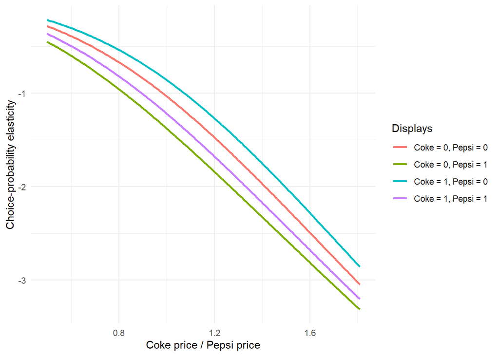

```r
# Price elasticity across all four display combinations.
elasticity_grid <- expand.grid(
  pratio = seq(price_range[[1]], price_range[[2]], length.out = 150),
  disp_coke = 0:1, disp_pepsi = 0:1)
elasticity_grid$elasticity <- slopes(
  logit, variables = "pratio", slope = "eyex", type = "response",
  newdata = elasticity_grid)$estimate
elasticity_grid$display <- with(elasticity_grid,
  paste0("Coke = ", disp_coke, ", Pepsi = ", disp_pepsi))
ggplot(elasticity_grid, aes(pratio, elasticity, colour = display)) +
  geom_line(linewidth = 1) +
  labs(x = "Coke price / Pepsi price", y = "Choice-probability elasticity",
       colour = "Displays") + theme_minimal()
```

The average elasticity is $N^{-1}\sum_i x_i m_i/p_i$.  
It is generally different from $\bar{x}\,\overline{m}/\bar{p}$ or an elasticity at mean covariates.  
Compare the four curves; a display need not make the response more inelastic under every specification.

### Step 6 · Price and display together

**Question:** Does the estimated probability-scale price effect differ by display status?  
**Prediction:** by R8, even the *additive* model implies different slopes, and the sign of that induced difference depends on whether $\eta_0$ lies above or below $-\beta_C/2$.  
**Action:** first read the induced interaction from the additive model; then fit the product term and decompose.

```r
slope_grid <- expand.grid(pratio = c(0.9, 1.3),
                          disp_coke = 0:1, disp_pepsi = 0)
# Additive model: no product term, yet slopes differ by display status.
cbind(slope_grid,
      slope = slopes(logit, variables = "pratio", newdata = slope_grid)$estimate,
      eta0  = b[["(Intercept)"]] + b[["pratio"]] * slope_grid$pratio)
```

```
  pratio disp_coke disp_pepsi      slope       eta0
1    0.9         0          0 -0.4969351  0.1268046
2    1.3         0          0 -0.4466644 -0.6714921
3    0.9         1          0 -0.4714422  0.1268046
4    1.3         1          0 -0.4863858 -0.6714921
```

```r
c(threshold = -b[["disp_coke"]] / 2)   # R8: sign flips where eta0 = -beta_C / 2
```

```
 threshold
-0.1757996
```

```r
# The price ratio at which eta0 = -beta_C / 2 (no displays for Pepsi).
c(pratio_flip = (-b[["disp_coke"]] / 2 - b[["(Intercept)"]]) / b[["pratio"]])
```

```
pratio_flip
   1.051625
```

**Read the output:** at which of the two prices does the display flatten the price slope, and at which does it steepen it?  
Below `pratio_flip` the no-display index lies above the threshold, so the display flattens the slope; above it the display steepens the slope.  
All of this comes from a model with no product term.

```r
# Product term with the price ratio centred at parity (pratio = 1).
logit_interaction <- glm(coke ~ I(pratio - 1) * disp_coke + disp_pepsi,
                         family = binomial(link = "logit"), data = coke)
logit_interaction_raw <- glm(coke ~ pratio * disp_coke + disp_pepsi,
                             family = binomial(link = "logit"), data = coke)

# Centring changes only the intercept and the display main effect.
coef_names <- c("(Intercept)", "pratio", "disp_coke", "disp_pepsi", "pratio:disp_coke")
round(rbind(uncentred = setNames(coef(logit_interaction_raw), coef_names),
            centred   = setNames(coef(logit_interaction), coef_names)), 3)
```

```
          (Intercept) pratio disp_coke disp_pepsi pratio:disp_coke
uncentred       1.570 -1.683     2.107     -0.606           -1.923
centred        -0.112 -1.683     0.184     -0.606           -1.923
```

```r
# Likelihood-ratio test of the product term: a log-odds-scale question.
anova(logit, logit_interaction, test = "Chisq")
```

```
Analysis of Deviance Table

Model 1: coke ~ pratio + disp_coke + disp_pepsi
Model 2: coke ~ I(pratio - 1) * disp_coke + disp_pepsi
  Resid. Df Resid. Dev Df Deviance Pr(>Chi)
1      1136     1418.9
2      1135     1411.2  1    7.717  0.00547 **
---
Signif. codes:  0 '***' 0.001 '**' 0.01 '*' 0.05 '.' 0.1 ' ' 1
```

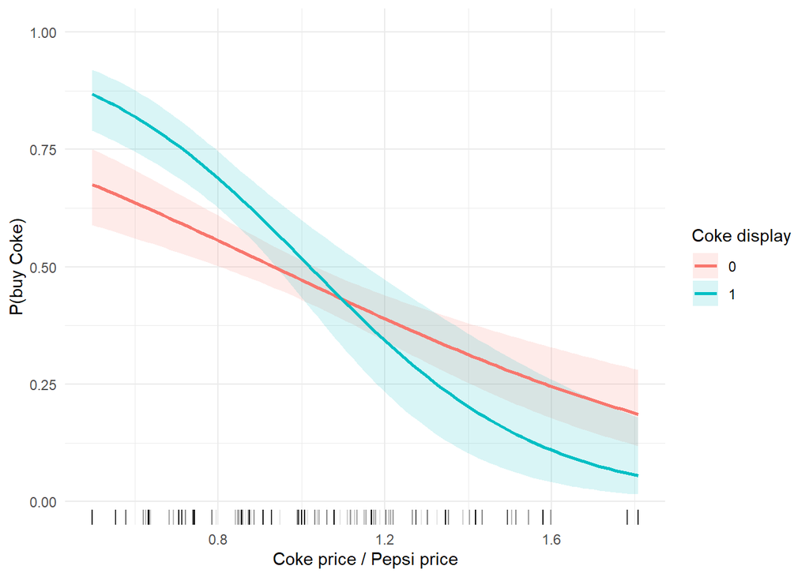

```r
interaction_grid <- expand.grid(
  pratio = seq(price_range[[1]], price_range[[2]], length.out = 100),
  disp_coke = 0:1, disp_pepsi = 0)
interaction_plotdat <- as_tibble(predictions(logit_interaction,
                                             newdata = interaction_grid))
ggplot(interaction_plotdat, aes(pratio, estimate,
                                colour = factor(disp_coke), fill = factor(disp_coke))) +
  geom_ribbon(aes(ymin = conf.low, ymax = conf.high), alpha = 0.15, colour = NA) +
  geom_line(linewidth = 1) +
  geom_rug(data = coke_in_range, aes(x = pratio), inherit.aes = FALSE,
           sides = "b", alpha = 0.1) +
  coord_cartesian(ylim = c(0, 1)) +
  labs(colour = "Coke display", fill = "Coke display",
       x = "Coke price / Pepsi price", y = "P(buy Coke)") + theme_minimal()
```

```r
# Price slopes at two prices under each display status.
slopes(logit_interaction, variables = "pratio", newdata = slope_grid)
```

```
 Estimate Std. Error      z Pr(>|z|)     S  2.5 % 97.5 %
   -0.420     0.0807  -5.21   <0.001  22.3 -0.579 -0.262
   -0.383     0.0642  -5.97   <0.001  28.6 -0.509 -0.257
   -0.860     0.1728  -4.98   <0.001  20.6 -1.199 -0.522
   -0.706     0.0569 -12.41   <0.001 115.0 -0.817 -0.594

Term: pratio
Type: response
Comparison: dY/dX
```

```r
# R8 decomposition by hand (centred parametrization: x enters as x - 1).
bi_all <- coef(logit_interaction)
bi <- c(alpha = bi_all[["(Intercept)"]],
        bP    = bi_all[["I(pratio - 1)"]],
        bC    = bi_all[["disp_coke"]],
        bPC   = bi_all[["I(pratio - 1):disp_coke"]])
decompose <- function(x) {
  e0 <- bi[["alpha"]] + bi[["bP"]] * (x - 1)
  e1 <- e0 + bi[["bC"]] + bi[["bPC"]] * (x - 1)
  c(pratio = x,
    product_term = bi[["bPC"]] * dlogis(e1),
    link_induced = bi[["bP"]] * (dlogis(e1) - dlogis(e0)),
    total        = (bi[["bP"]] + bi[["bPC"]]) * dlogis(e1) -
                   bi[["bP"]] * dlogis(e0))
}
rbind(decompose(0.9), decompose(1.3))
```

```
     pratio product_term link_induced      total
[1,]    0.9   -0.4588787   0.01874076 -0.4401379
[2,]    1.3   -0.3763317   0.05366597 -0.3226658
```

```r
# Probability-scale contrasts with delta-method SEs, at both prices.
# Rows of slope_grid: (0.9, 0), (1.3, 0), (0.9, 1), (1.3, 1).
bind_rows(
  `pratio = 0.9` = as_tibble(slopes(logit_interaction, variables = "pratio",
                                    newdata = slope_grid, hypothesis = "b3 - b1 = 0")),
  `pratio = 1.3` = as_tibble(slopes(logit_interaction, variables = "pratio",
                                    newdata = slope_grid, hypothesis = "b4 - b2 = 0")),
  .id = "at") %>%
  select(at, estimate, std.error, conf.low, conf.high)
```

```
# A tibble: 2 × 5
  at           estimate std.error conf.low conf.high
  <chr>           <dbl>     <dbl>    <dbl>     <dbl>
1 pratio = 0.9   -0.440    0.176    -0.785   -0.0950
2 pratio = 1.3   -0.323    0.0883   -0.496   -0.150
```

**Misleading conclusion to challenge:** “The coefficient on `pratio:disp_coke` is the interaction effect in percentage points.” It is an index-scale (log-odds) coefficient; $e^{\beta_{PC}}$ is a ratio of odds ratios.  
For a binary display, inspect $\partial p(x,1)/\partial x-\partial p(x,0)/\partial x$ at stated $x$ (or a finite difference-in-differences for a stated price change).  
The `total` column should match the difference in the slope rows and the `estimate` in the contrast table.  
The additive model can imply different probability slopes even without a product term.  
In these data the product-term component dominates the decomposition, so the sign of $\beta_{PC}$ and the probability-scale interaction agree.  
The heat-pump example below shows the opposite case, where the link does all the work.  
The likelihood-ratio test and the Wald test on the product coefficient answer the log-odds question; the contrast table answers the probability-scale question.  
With these observational data, inspect whether the difference changes sign over the selected prices; do not assume it does.  
The fitted product term adds flexibility but does not establish a causal display effect.  
The Ai–Norton paper explains why probability-scale interactions need their own evaluation and uncertainty.

## 4. AI audit

Provide an AI tool with the fitted `summary(logit_interaction)` and the table of predictions and slopes from class.  
Ask:

> Write a recommendation to a store manager about Coke’s relative price and Coke displays. Interpret the price slope, the 0-to-1 display change, the price elasticity, and the price × display interaction. Give the profile at which each effect applies; distinguish association from a causal claim. If a quantity cannot be read directly from the coefficients, say what predictions you would compute.

Audit its response: (1) stated baseline and display conditions; (2) percentage points versus percent changes versus odds ratios; (3) binary display comparison rather than derivative; (4) probability-scale interaction rather than the product coefficient, and whether it names its scale; (5) observational limitations and uncertainty.  
If the answer is sound, follow up: “Re-evaluate the interaction at a low and a high predicted probability, and show the four relevant probabilities for a price change from 1.0 to 1.1 under each display status.  
Then state the same interaction on the log-odds scale and explain why the two answers differ.”

## 5. Exit problem

Two shoppers share the same negative logit price coefficient, but their starting probabilities are 0.50 and 0.95.  
Must a small price change alter their probabilities equally?

**Answer**

**Answer:** no.  
The local slopes contain $p(1-p)$, which is 0.25 versus 0.0475 before multiplying by the coefficient.  
Saying “yes, same coefficient” mistakes the model for a linear probability model; saying “0.95 changes more” mistakes a high probability for a steep curve.  
**Follow-up:** does the price change alter their *odds* by the same factor?  
Yes, by $e^{\beta_P\Delta x}$ for both (R2).

**Back to the hook:** compare your two recorded votes with Steps 2 and 6.  
Which prediction would you change, and which result (R3 or R8) changes it?

## Assessment connection

**New setting: heat-pump adoption.** Let $Y=1$ for adoption, $x$ be annual heating costs in thousands of kroner, and $D=1$ if a household received an information visit.  
The exam supplies a *hypothetical* fitted logit table:

| Heating cost | No visit | Visit |
| --- | --- | --- |
| 20 | 0.20 | 0.32 |
| 30 | 0.37 | 0.52 |

**Part A — individual, closed book.**  
(1) What is the visit difference in adoption probability at cost 20, and may it be read as causal?  
(2) Is the visit difference the same at cost 30?  
(3) By how much does raising cost from 20 to 30 change the predicted probability without and with a visit, and what is the difference between those two changes called?  
(4) A classmate calls the no-visit change in (3) “a 17% elasticity”. Evaluate the claim.  
(5) *Values of $\ln$ supplied.* Compute the log-odds in all four cells and the log-odds interaction.  
How much of the probability-scale interaction in (3) is induced by the link?

**Answer, Part A**

1. $0.32-0.20=0.12$, or 12 percentage points.  
   It is not automatically causal: we do not know how visits were assigned.
2. No: the visit difference is $0.52-0.37=0.15$, or 15 points, at cost 30.
3. Raising cost from 20 to 30 changes the predicted probability by 17 points without and 20 points with a visit.  
   Their three-point difference, which equals $15-12$, is a finite probability-scale interaction for that exact cost interval.
4. The 17-point change is not “a 17% elasticity”.  
   A point elasticity concerns local proportional changes in a continuous regressor and in the probability; this is a finite change in percentage points.
5. The log-odds are $-1.386$ and $-0.754$ at cost 20, and $-0.532$ and $0.080$ at cost 30.  
   The visit shifts the log-odds by $0.632$ at cost 20 and $0.612$ at cost 30.  
   The cost increase shifts them by $0.854$ without and $0.834$ with a visit.  
   The log-odds interaction is $-0.020$: slightly *negative*, while the probability-scale interaction is $+3$ points.  
   So the whole probability-scale interaction is induced by the link (R8), and the two scales even disagree in sign (R8, lesson 2).  
   The reason: the visit group moves through $p=0.5$, where the curve is steepest.

**Part B — AI allowed.** Critique: “Visits work better for high-cost households, so target them.”  
Ask for uncertainty around the probability-scale contrast and information about how visits were assigned.  
*Insufficient:* repeats the claim or reads a product coefficient.  
*Competent:* compares the 12- and 15-point visit differences and qualifies causality.  
*Strong:* also recognizes how much of the pattern is a scale effect (item 5), explains whether “works better” is still true on the probability scale for a manager who counts adopters, and evaluates uncertainty, policy-relevant profiles, selection into visits, and what new evidence would change the decision.

## Appendix A · The likelihood, its geometry, and the variance of $\hat{\boldsymbol\beta}$

*Reference material, beyond textbook §16.2.3.*

**Log-likelihood.** With independent observations and $p_i=F(\mathbf{x}_i'\boldsymbol\beta)$,

$$\ell(\boldsymbol\beta)=\sum_{i=1}^N\big[y_i\ln F(\eta_i)+(1-y_i)\ln\{1-F(\eta_i)\}\big].$$

**Score.** Differentiating,

$$\frac{\partial\ell}{\partial\boldsymbol\beta}=\sum_{i=1}^N\frac{(y_i-F_i)\,f_i}{F_i(1-F_i)}\,\mathbf{x}_i ,
\qquad
\text{logit: }\frac{\partial\ell}{\partial\boldsymbol\beta}=\sum_{i=1}^N(y_i-p_i)\,\mathbf{x}_i=\mathbf{X}'(\mathbf{y}-\mathbf{p}),$$

because $f=F(1-F)$ for the logistic.  
In probit the ratio $(y_i-\Phi_i)\phi_i/[\Phi_i(1-\Phi_i)]$ is a *generalized residual*.

**Geometry.** The logit first-order conditions $\mathbf{X}'(\mathbf{y}-\hat{\mathbf{p}})=\mathbf{0}$ have exactly the form of the OLS normal equations $\mathbf{X}'(\mathbf{y}-\mathbf{X}\mathbf{b})=\mathbf{0}$: the residual vector is orthogonal to the column space of $\mathbf{X}$.  
The difference is that the fitted vector $\hat{\mathbf{p}}=\Lambda(\mathbf{X}\hat{\boldsymbol\beta})$ lies on a curved $K$-dimensional surface inside $(0,1)^N$ rather than on the flat subspace $\operatorname{col}(\mathbf{X})$.  
That curvature is why there is no closed form.  
Two immediate implications:

- With an intercept, $\sum_i\hat p_i=\sum_i y_i$: the mean fitted probability equals the sample share of Coke buyers.
- With a dummy such as `disp_coke`, the fitted and observed Coke shares are equal within the display group, and hence also outside it.

**Hessian and concavity.** For logit,

$$\frac{\partial^2\ell}{\partial\boldsymbol\beta\,\partial\boldsymbol\beta'}=-\sum_{i=1}^N p_i(1-p_i)\,\mathbf{x}_i\mathbf{x}_i'=-\mathbf{X}'\mathbf{W}\mathbf{X},\qquad \mathbf{W}=\operatorname{diag}\{p_i(1-p_i)\}.$$

If $\mathbf{X}$ has full column rank, this is negative definite, so $\ell$ is strictly concave and any maximum is unique. (The probit log-likelihood is also globally concave.) A maximum can fail to exist under *perfect separation*, when some combination of regressors predicts $y$ exactly; the coefficients then diverge.

**Newton–Raphson is iteratively reweighted least squares.** A Newton step is

$$\boldsymbol\beta^{(t+1)}=\boldsymbol\beta^{(t)}+(\mathbf{X}'\mathbf{W}\mathbf{X})^{-1}\mathbf{X}'(\mathbf{y}-\mathbf{p})
=(\mathbf{X}'\mathbf{W}\mathbf{X})^{-1}\mathbf{X}'\mathbf{W}\mathbf{z},
\qquad
\mathbf{z}=\mathbf{X}\boldsymbol\beta^{(t)}+\mathbf{W}^{-1}(\mathbf{y}-\mathbf{p}).$$

Each iteration is a weighted least-squares *projection* of a working response $\mathbf{z}$ onto $\operatorname{col}(\mathbf{X})$ in the metric defined by $\mathbf{W}$.  
This is literally what `glm()` does.

**Variance.** Under correct specification, $\hat{\boldsymbol\beta}\overset{a}{\sim}N\big(\boldsymbol\beta,\,(\mathbf{X}'\mathbf{W}\mathbf{X})^{-1}\big)$, estimated by plugging in $\hat p_i$.  
The weights $p_i(1-p_i)$ are the Bernoulli variances from the retrieval question.  
Heteroskedasticity is *modelled* inside the likelihood rather than corrected afterwards, which is why textbook §16.2.7 says heteroskedasticity-robust standard errors have no special role here.

```r
X <- model.matrix(logit); y <- coke$coke

# Score at the MLE is zero: residuals are orthogonal to col(X).
crossprod(X, y - fitted(logit))
```

```
                     [,1]
(Intercept) -1.390621e-06
pratio      -2.298814e-06
disp_coke    2.460625e-07
disp_pepsi  -1.587285e-06
```

```r
c(mean_fitted = mean(fitted(logit)), mean_y = mean(y))
```

```
mean_fitted      mean_y
  0.4473684   0.4473684
```

```r
# Newton-Raphson / IRLS from zero reproduces glm().
beta <- rep(0, ncol(X))
for (iter in 1:8) {
  eta_t <- drop(X %*% beta); p_t <- plogis(eta_t); w <- p_t * (1 - p_t)
  z_t   <- eta_t + (y - p_t) / w
  beta  <- drop(solve(crossprod(X, w * X), crossprod(X, w * z_t)))
}
w_hat <- fitted(logit) * (1 - fitted(logit))
cbind(IRLS = beta, glm = coef(logit),
      se_by_hand = sqrt(diag(solve(crossprod(X, w_hat * X)))),
      se_glm = sqrt(diag(vcov(logit))))
```

```
                  IRLS        glm se_by_hand    se_glm
(Intercept)  1.9229720  1.9229720  0.3258327 0.3258168
pratio      -1.9957416 -1.9957416  0.3145872 0.3145687
disp_coke    0.3515992  0.3515992  0.1585398 0.1585345
disp_pepsi  -0.7309857 -0.7309857  0.1678376 0.1678302
```

## Appendix B · The delta method for marginal effects

A marginal effect at profile $\mathbf{x}_0$ is a smooth function of the estimates, $g(\boldsymbol\beta)=f(\mathbf{x}_0'\boldsymbol\beta)\,\beta_k$.  
By a first-order expansion around $\boldsymbol\beta$,

$$\operatorname{Var}\big(g(\hat{\boldsymbol\beta})\big)\approx\nabla g'\,\operatorname{Var}(\hat{\boldsymbol\beta})\,\nabla g,
\qquad
\nabla g=f(\eta_0)\,\mathbf{e}_k+\beta_k\,f'(\eta_0)\,\mathbf{x}_0 ,$$

where $\mathbf{e}_k$ is the $k$-th unit vector and, for logit, $f'(\eta_0)=p_0(1-p_0)(1-2p_0)$.  
For a finite contrast $g=F(\mathbf{x}_1'\boldsymbol\beta)-F(\mathbf{x}_0'\boldsymbol\beta)$, the gradient is $f(\eta_1)\mathbf{x}_1-f(\eta_0)\mathbf{x}_0$.  
The same logic gives standard errors for probability-scale interaction contrasts. `marginaleffects` computes $\nabla g$ numerically.

```r
V <- vcov(logit)
grad <- p0 * (1 - p0) * c(0, 1, 0, 0) +                     # f(eta0) e_k
        b[["pratio"]] * p0 * (1 - p0) * (1 - 2 * p0) * x0     # beta_k f'(eta0) x0
c(se_by_hand = sqrt(drop(t(grad) %*% V %*% grad)),
  se_package = slopes(logit, variables = "pratio", newdata = profile0)$std.error)
```

```
se_by_hand se_package
0.07531643 0.07531703
```

## Appendix C · From Gumbel errors to the logit

Let $\varepsilon_{C},\varepsilon_{P}$ be independent standard Gumbel, with CDF $G(\varepsilon)=\exp(-e^{-\varepsilon})$ and density $g(\varepsilon)=e^{-\varepsilon}\exp(-e^{-\varepsilon})$, and let $\Delta=V_C-V_P$.  
Conditioning on $\varepsilon_C$,

$$P(U_C>U_P)=\int_{-\infty}^{\infty}G(\Delta+\varepsilon)\,g(\varepsilon)\,d\varepsilon
=\int_{-\infty}^{\infty}\exp\!\big(-e^{-\varepsilon}(1+e^{-\Delta})\big)\,e^{-\varepsilon}\,d\varepsilon .$$

Substitute $t=e^{-\varepsilon}$, $dt=-e^{-\varepsilon}d\varepsilon$:

$$P(U_C>U_P)=\int_0^\infty e^{-t(1+e^{-\Delta})}\,dt=\frac{1}{1+e^{-\Delta}}=\Lambda(V_C-V_P)=\frac{e^{V_C}}{e^{V_C}+e^{V_P}} .$$

The last form generalizes directly to $J$ alternatives (multinomial and conditional logit in Lecture 2).  
Independence of the Gumbel errors is what later produces the IIA property.

## Instructor notes

**Instructor-only teaching notes**

- Keep the lab moving: run prepared code, ask for predictions before each reveal, and interpret only the needed output.  
  Keep the LPM discussion brief.
- The theory block states R1–R8 and uses them; the collapsed derivations are pre-class work.  
  If students arrive unprepared, cut R5–R7 to one sentence each and keep R1 and R8, which carry the lecture’s two main ideas (identification up to scale; interactions depend on scale). Interpret fitted effects as associations unless a causal identification argument is provided.
- The textbook’s 21-person `transport` example is useful for hand calculations but too small for this lab’s exploratory interactions.
- Do not compare probit/logit coefficients numerically.  
  Compare predicted probabilities, slopes, identified ratios, and their uncertainty.
- For uncertainty on a specific interaction contrast, calculate the contrast and its standard error as a joint function of estimated parameters (delta method, Appendix B, or bootstrap); a Wald test of the product coefficient alone answers the log-odds-scale question.
- The two applications sit at opposite ends of R8: in the Coke data the product term dominates the probability-scale interaction; in the heat-pump table the link does all the work and the log-odds interaction has the opposite sign.  
  Point this out when you reach the assessment connection.
- Centring `pratio` at 1 makes the display main effect interpretable at price parity; the uncentred $\beta_C$ refers to `pratio = 0`, below the observed minimum.
- Ai & Norton (2003), *Economics Letters* 80:123–129, supplied reading: interactions in nonlinear binary response models.
- Package reference: https://marginaleffects.com/chapters/slopes.html and https://marginaleffects.com/chapters/interactions.html